# SpectralTAD: Defining Hierarchy of Topologically Associated Domains Using Graph Theoretical Clustering

Mikhail Dozmorov  
7/29/2019

### The Genome

- The genome refers to the entirety of an organisms DNA and genetic information
- It is made up of structures called chromosomes which contain molecules of DNA
- In total, each person has 46 chromosomes with each containing unique genetic information

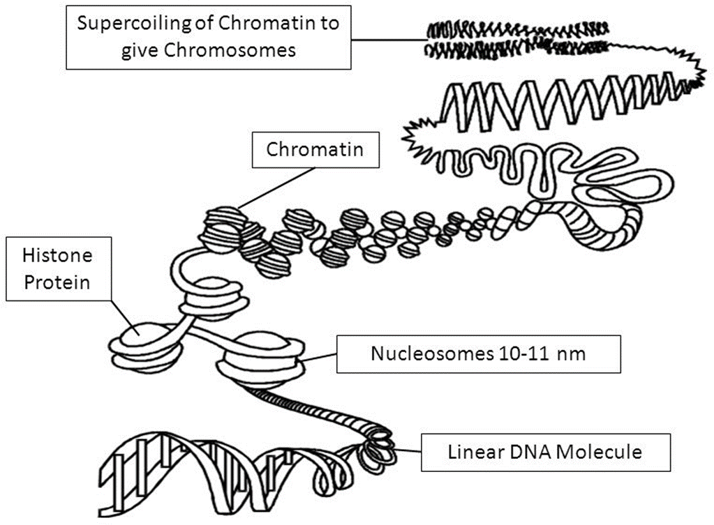

### 3D Genomics

- Chromosomes are 3D structures with loops
- Areas of the chromosome measured on a linear scale might actually interact to a high degree on a 3D scale due to looping
- Hi-C sequencing is a form of sequencing that allows us to identify these loops

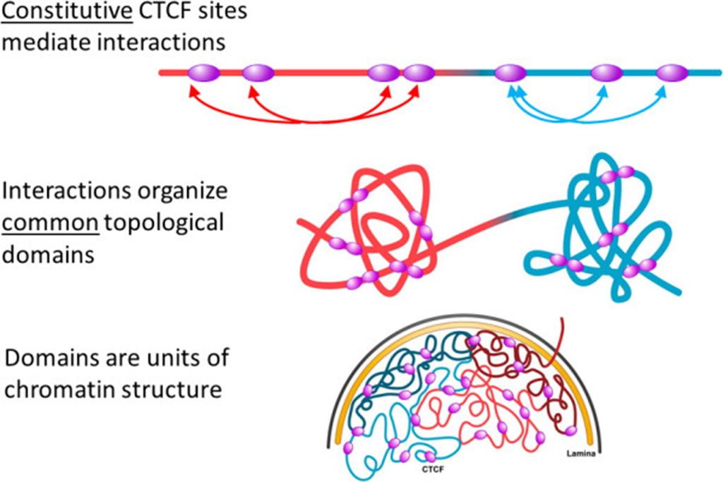

### Hi-C Data as a matrix

- The genome (chromosome) is binned to equally sized regions
- Data is represented by a symmetric matrix of contacts \( C_{ij} \) where entry \( ij \) corresponds to the number of times region \( i \) comes into contact with region \( j \)
- Distance is measured in number of basepairs
- A parameter called resolution determines region size

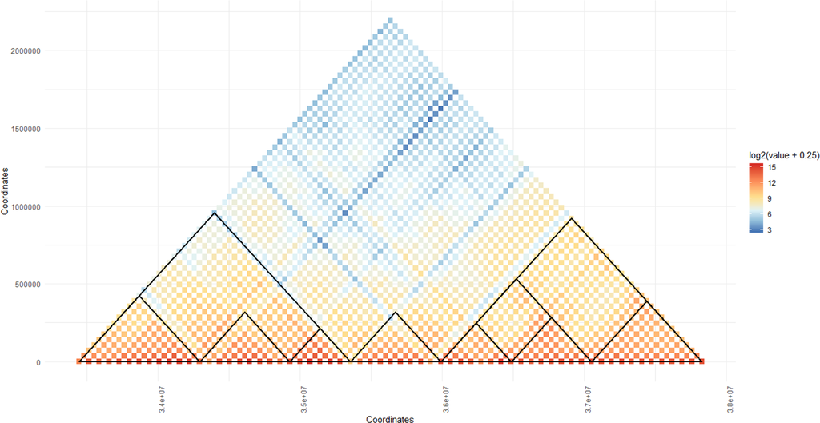

### Topologically Associated Domains (TADs)

- TADs are regions of the genome that exhibit exceptionally high interconnectedness
- Triangular structures with sharp boundaries
- Boundaries are highly associated with important genomic features

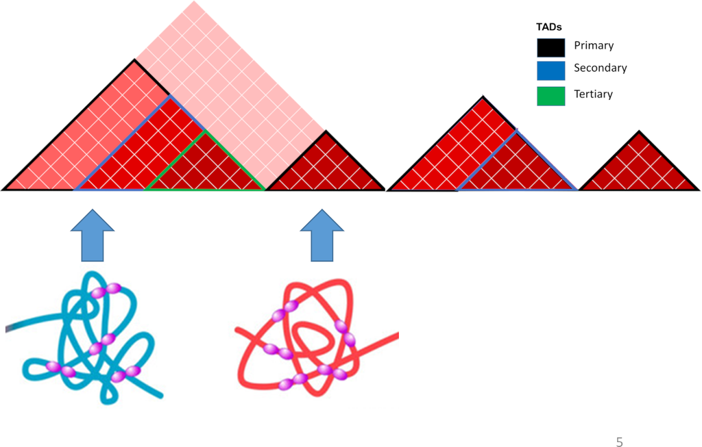

### TADs are hierarchical

- Organized in a hierarchy
- Characterized by large “meta-TADs” containing small “sub-TADs”
- Level of hierarchy has an effect on biological relevance

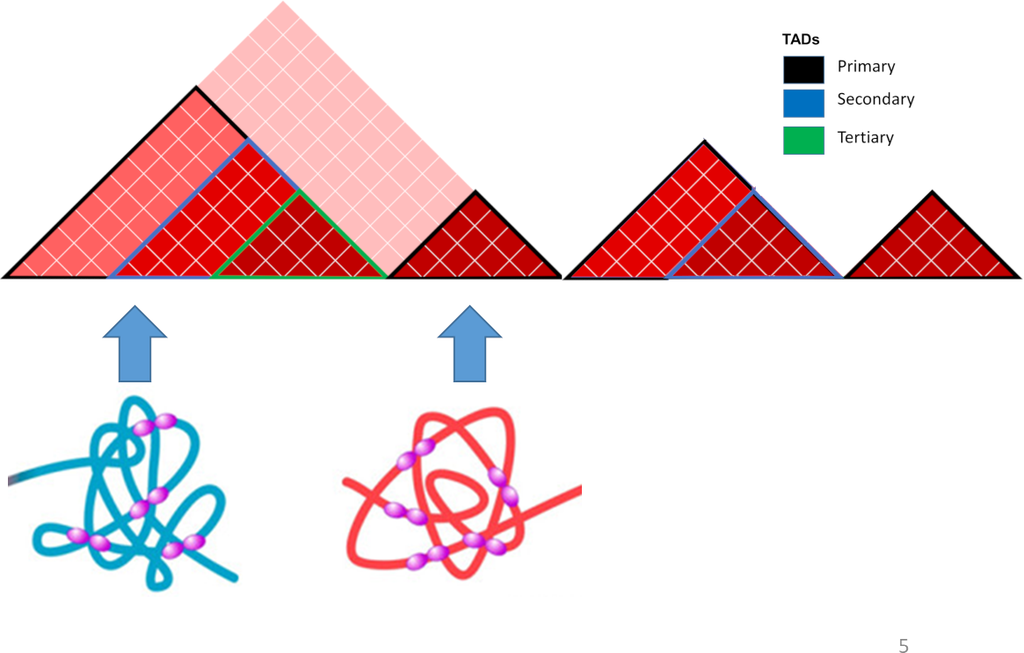

### Types of Boundaries and TADs

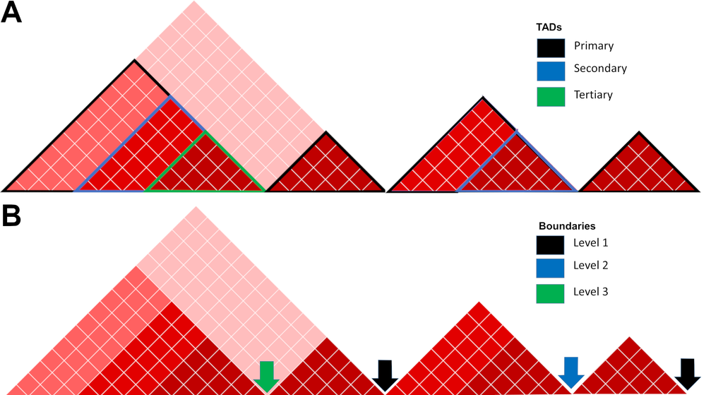

### Why are TADs Important?

- Act as walls inhibiting promoter-enhancer interaction and gene expression
- Disruption is potential mechanism for the spread of cancer
- Can be edited using CRISPR
- Associated with the location of CTCF and cohesion
- Highly conserved
- Many possible other functions (Largely unexplored)

### Graph Representation of 3D Data

- Hi-C data has a natural graph structure
- In mathematical graph theory is defined by vertices V and edges E
- Vertices are points and edges are lines connecting the points together
- Vertices and edges are stored in an adjacency matrix \( A_{ij} \) where \( ij \) is the number of edges between a given set of vertices \( ij \)

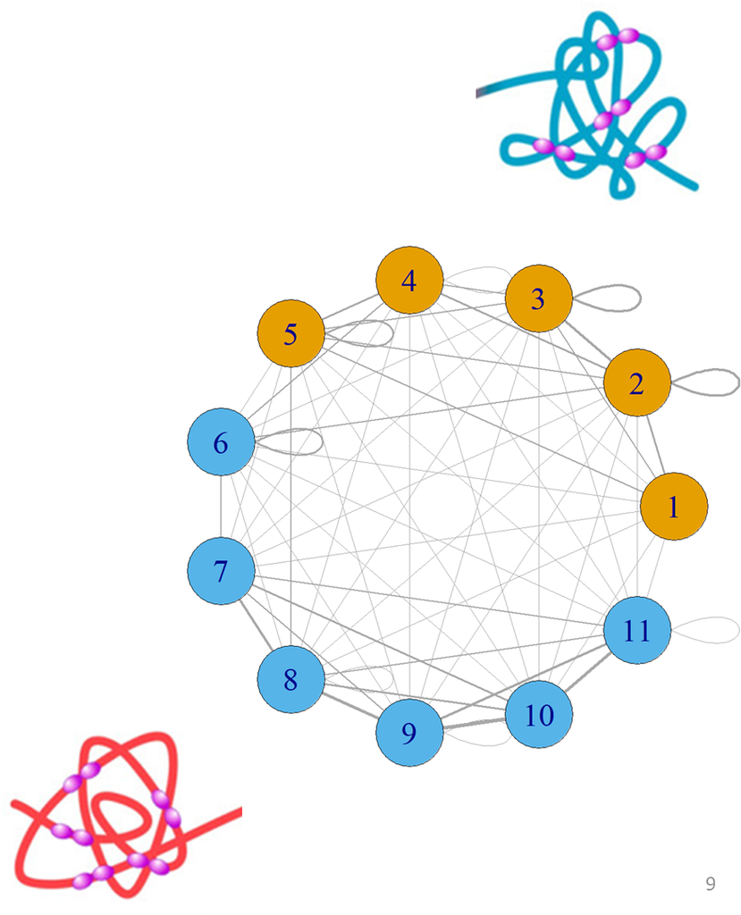

### Traditional Spectral Clustering

- Specifically designed to cluster graphs
- Works by projecting the data into a lower dimensional space
- Excels on noisy and non-normally distributed data (Hi-C data)
- Clusters the adjacency matrix \( A_{nxn} \)

### How to perform spectral clustering

- Calculate the Laplacian:

\[ D = diag(A\mathbf{1_n}) \]

\[ \bar{L} = D^{-\frac{1}{2}}AD^{-\frac{1}{2}} \]

- Calculate the eigenvectors of the Laplacian matrix (graph spectrum):

\[ \bar{L}\mathbf{v} = \lambda\mathbf{v} \]

- Normalize the eigenvectors and cluster

### Spectral clustering with eigenvector gaps

- Rows and columns of contact matrices are naturally ordered
- TADs are continuous
- Ordering allows us to reframe clustering as finding cut points
- We propose a simple, novel, approach to clustering ordered data using gaps between consecutive eigenvectors

### Step 1: Plot the non-normalized eigenvectors

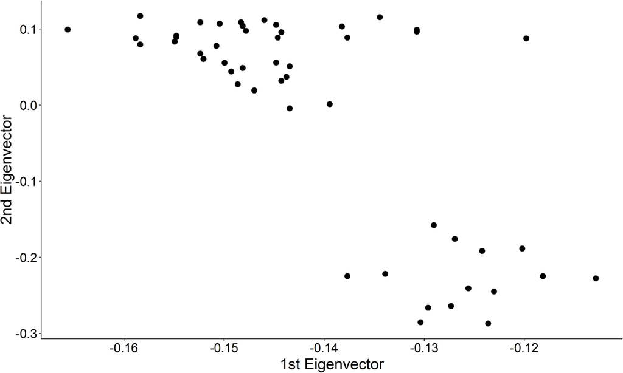

### Step 2: Project on to Unit Circle

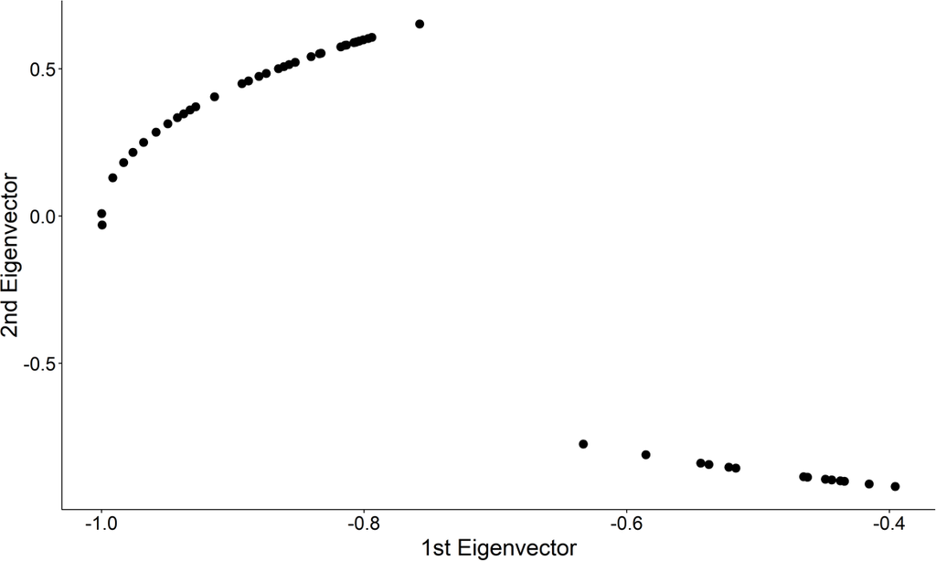

### Step 3: Find the k-largest gaps and partition

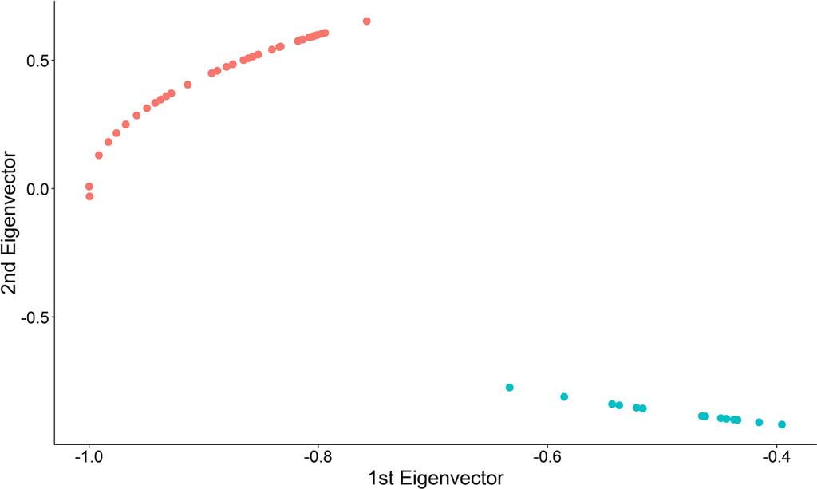

### Step 3: Find the k-largest gaps and partition

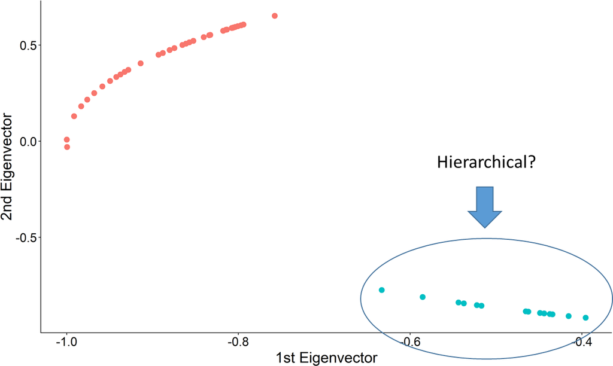

### Silhouette Score

- A strong TAD should have a high level of interconnectedness within the TAD and a low-level outside of the TAD
- This can be quantified using silhouette score:

\[ s(i) = \frac{b(i)-a(i)} {max(a(i), b(i))} \]

- Here, we define distance between two points \( i \) and \( j \) as \( \frac{1}{1+C_{ij}} \)

### Windowed Spectral Clustering

- We know the biologically maximum TAD size (2 million bp)
- For a given region we only need to consider points within the maximum TAD size
- We can use a 2 million bp sliding window to perform spectral clustering and aggregate
- Advantages of the sliding window
  - Converts spectral clustering from cubic \( (O(n^{3})) \) complexity to linear \( (O(n)) \)
  - Naturally reduces noise from redundant regions

### SpectralTAD algorithm

1. Cut out a window from the matrix equal to the maximum size of a TAD
2. Find the graph spectrum of the window and calculate eigenvector gap
3. Find n-largest gap values
4. Find the set of clusters that maximize the silhouette score
5. Slide the window to the next group of loci and repeat

### Determining a hierarchy of TADs

- TADs are hierarchical in nature
- Organized into large meta-TADs with sub-TADs within them
- Need to find sub-TADs within those detected by sliding window
- We use a novel metric called boundary score to achieve this
- Boundary score is just the z-score for each eigenvector gap
- For each initial TAD detected:
  - Calculate the boundary score for each region within the TAD
  - If any distance is greater than 1.96, this is a sub-TAD boundary
  - Repeat for all sub-TADs until no z-score is greater than 1.96
- Alternatively, we can simply repeat silhouette score maximization

### TAD Calling

- Refers to methods designed to find TAD boundaries
- Good TAD callers must satisfy five criteria
  - High quality TADs
  - Speed
  - Robustness to sequencing depth
  - Robustness to sparsity
  - Biologically significant boundaries
- We compared:
  - SpectralTAD
  - rGMAP
  - TopDom
  - OnTAD
  - HiCSeg

### SpectralTAD is fast

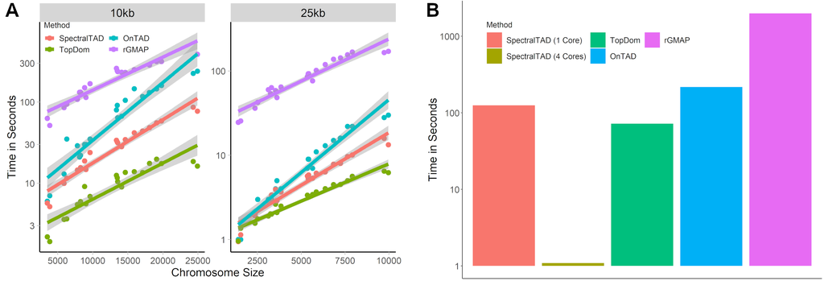

### Sparsity

- One of the main biases in HiC data
- Characterized by random zeros in the contact matrix
- Simulated by replacing a certain percentage of contact matrix with zeros

### SpectralTAD is robust to sparsity

- The percentages indicate the percentage of the matrix replaced with zeros.
- Jaccard refers to the similarity between the TADs detected and manually annotated TADs. Results are summarized across 25 simulated matrices
- Our method is better than other methods, excluding - HiCSeg, at all levels of sparsity
- Other hierarchical TAD callers (OnTAD and rGMAP) perform relatively poorly

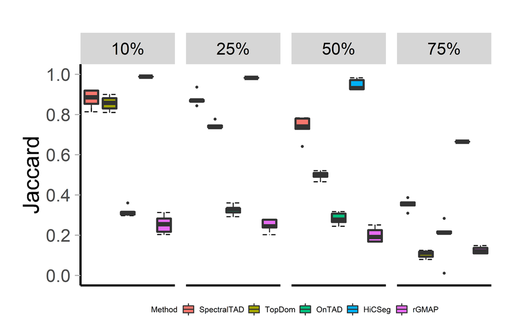

### Sequencing depth

- Sequencing methods have a set number of possible reads per chromosome
- Characterized by different magnitudes of total contacts
- Simulated by randomly removing contacts one at a time

### SpectralTAD is robust to downsampling

- The fraction indicates the proportion of contacts removed.
- Jaccard refers to the similarity between the TADs detected and manually annotated TADs.
- Results are summarized across 20 simulated matrices
- Our method outperforms all other methods excluding HiCseg at all levels of downsampling

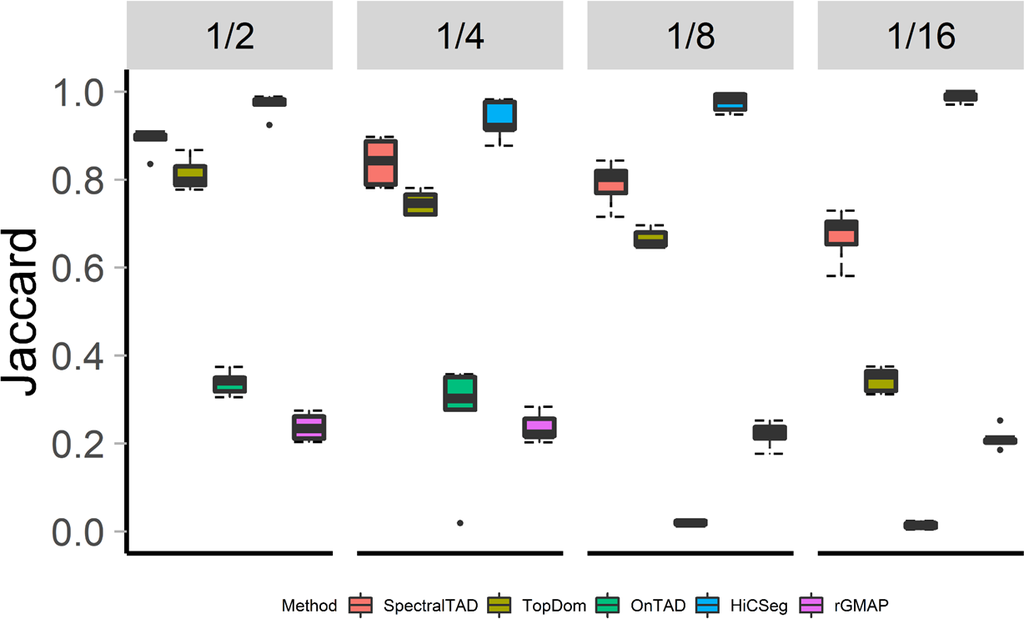

### Expression and depletion based on boundary type

[figure not shown]

### SpectralTAD Package

- Currently available and fully functional at http://bioconductor.org/packages/release/bioc/html/SpectralTAD.html
- Two main functions: SpectralTAD and SpectralTAD_Par
- First TAD caller designed to accept the three types of contact matrices (n x n, sparse and n x (n+3))
- Produces a simple 3 column bed file output for each hierarchy level

### Summary

- We have proposed a new approach for TAD detection based on spectral clustering
- We have introduced two novel methods (sliding window and eigenvector gap clustering) for improving clustering on ordered data with size restrictions
- The method was benchmarked against existing methods and has shown a significant improvement
- The method has been released in an R package available on Bioconductor

### Where to view the preprint

- Available at https://www.biorxiv.org/content/10.1101/549170v2